# Democracy

The basics

Carolina Torreblanca

University of Pennsylvania

**Global Development**: Intermediate Topics in Politics, Policy, and Data

PSCI 3200 - Spring 2026

## Agenda

1. Conceptualizing Democracy
2. Measuring Democracy
3. Majoritarian Threat to Democracy (Grossman et. al.)
4. On Wed: Democracy and development (And Fixed Effects)

## What is Democracy?

- Not an easy question to answer!
- One might even say polemic…
  - Etymology? **Demokratia** = demos + kratia
  - Is it about elections? About outcomes? About norms?
- Academics often talk about **minimalist** (procedural)
- and **maximalist** (substantive) conceptions of democracy.

## What is Democracy? The Minimalists

Democracy as a PROCEDURE for choosing and replacing who rules us

- Schumpeter: a system in which rulers are selected by competitive elections
- Popper: a system in which citizens can replace governments without bloodshed
- Przeworksi: a system in which citizens collectively decide by whom and, to some extent, how they will be governed

## What is Democracy? The Maximalists

“Thick’’ definition of democracy

- Democracy as system that **embodies** or a method for **realizing** extrinsic values
- Democracies classified based on **formal institutions** and rules, **how those institutions are used** in practice, and what **outcomes** they produce
  - Do the rules, the way they are used, and their consequences promote equality, accountability, participation, justice, dignity, security …

## Minimalists vs. Maximalists

Common critique of procedural conceptions of democracy:

- is that it is too thin and mostly electoral.
- But is it really that minimal?
  - What do we require to hold “free and fair” elections?
    - At least civil and political rights, neutral electoral machinery, stability, competing parties, etc…
    - Respect for the rules of the game …

## Minimalists vs. Maximalists

Common critique of maximalist perspective:

- Democracy becomes subjective
  - Whatever values we view as democratic need not be the other persons’ views
  - Hard to measure, hard to compare across time and space
- If democracy is only justifiable for its outcomes, we may risk autocracy during bad times

## Are you a maximalist or a minimalist?

What is a necessary condition for a system to be democratic?

- Does it need to hold elections?
- Does everyone need to be able to vote?
- Does everyone need to be able to run for office?
- Have an independent legislative body?
- Independent media?
- Economic equality?

## What is an autocracy

- A fundamentally residual category!

## Measuring democracy

1. Minimalist (Yes/No)
   - [Democracy-Dictatorship score](https://sites.google.com/site/joseantoniocheibub/datasets/dd) (ends in 2008 sadly)
     - Democracy if: Executive is elected, legislature is elected, more than one party, has been an alternation of power under current rules
2. Maximalist
   - [Polity IV/V (from -10 to 10)](https://www.systemicpeace.org/polityproject.html)
     - Spectrum of: competitiveness, openness, participation, checks and balances
   - [Freedom house](https://freedomhouse.org/countries/freedom-world/scores) (0-100)
     - Experts rate: access to political rights and civil liberties

## The Value of Democracy

1. *Per se*
   - The fairest system as normatively desirable.
   - Political freedom is human freedom.
2. Instrumental (i.e gets you something else)
   - The best way to prevent abuse is by making our rulers dependent on us.
   - We can select the most competent rulers.
   - Pacification of the political life.
   - Economic Development

## If Democracy is Valuable…

Then we want to keep it safe!

- Democracies are stronger when citizens hold politicians accountable
- But… what if people knowingly support antidemocratic governments or antidemocratic behavior from politicians?

## The Majoritarian Threat to Liberal Democracy

*Grossman, Kronick, Levendusky, and Meredith, 2022*

- Puzzle: voters often ignore or even support politicians’ power grabs. Why?
  - Extant research shows some people prefer nondemocratic governments (autocrats)
  - While others prioritize their partisan objectives over democratic principals (militants)
- But the authors suggest there is a third type …

## The Majoritarian Threat to Liberal Democracy

- Majoritarians:
- People who believe popular elected leaders are justified in taking legal but “antidemocratic” steps
- What do we mean by that?
- How to identify these people in the population?

## Research Design

- Two survey experiments. We will focus on the first one
- Vignette –> outgoing governor announces that he will appoint a replacement for a state SCJ instead of waiting for incoming governor from opposite party
  - Not **illegal** but not **“democratic”**
- Respondents are assigned to a treatment or control condition.
- What is the treatment?

## Research Design

Randomly assigned whether the outgoing governor is a co-partisan of respondents

- Outcomes?
  1. Do you approve of what the outgoing governor did?
  2. Do you think it’s consistent with democracy?
- Assumptions?
  1. Treatment and control groups are the same across all relevant dimensions, in expectation

## Theoretical Expectations

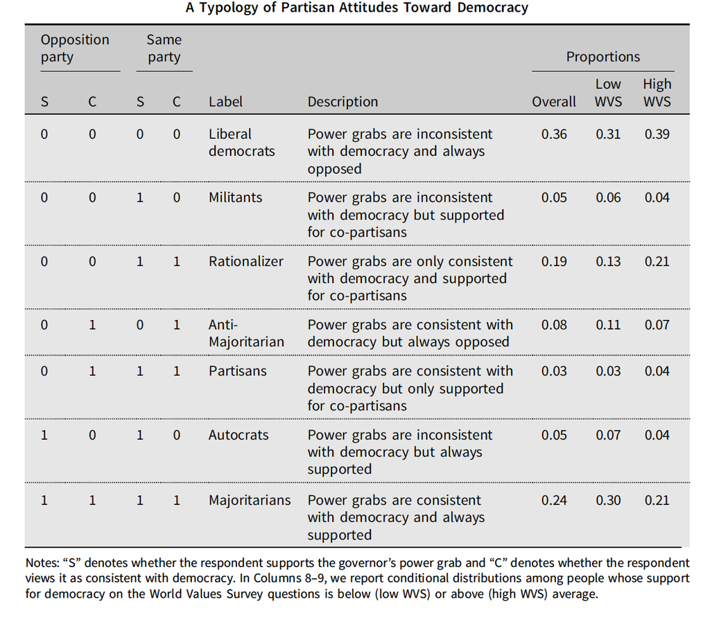

## Results

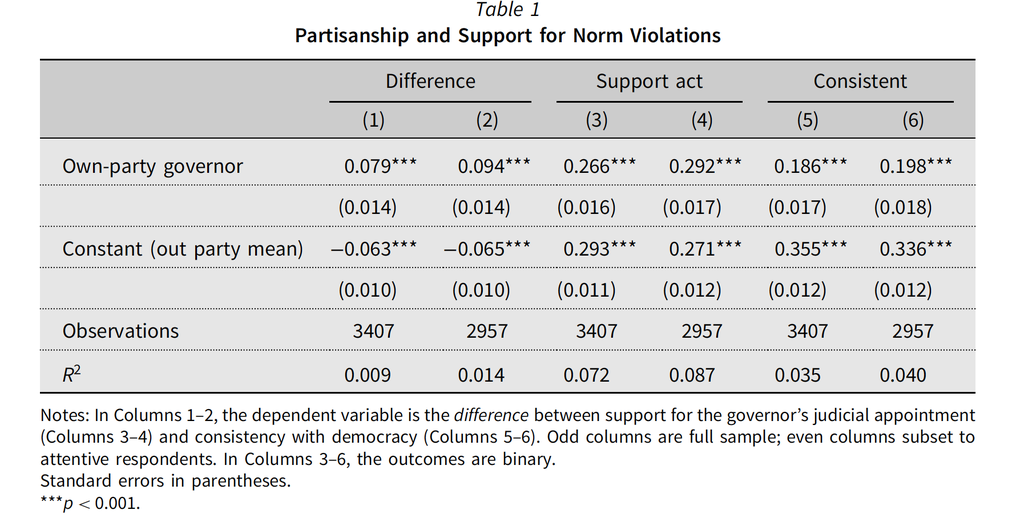

## Discussion

- Are majoritarians antidemocratic? Are partisans?
  - What would the minimalists say?
  - What would the maximalists say?
- What implications does the existence of majoritarians have for democratic quality?